# Displacement Risk Tracker

Asha Bazil, Hannah Wagner

December 15, 2020

```r
mapTheme <- function(base_size = 12) {
  theme(
    text = element_text( color = "black", size=12),
    plot.title = element_text(size = 12,colour = "black"),
    plot.subtitle=element_text(face="italic"),
    plot.caption=element_text(hjust=0),
    axis.ticks = element_blank(),
    panel.background = element_blank(),axis.title = element_blank(),
    axis.text = element_blank(),
    axis.title.x = element_blank(),
    axis.title.y = element_blank(),
    panel.grid.minor = element_blank(),
    panel.border = element_rect(colour = "black", fill=NA, size=2)
  )
}

plotTheme <- function(base_size = 12) {
  theme(
    text = element_text( color = "black", size=12),
    plot.title = element_text(size = 12,colour = "black"),
    plot.subtitle = element_text(face="italic"),
    plot.caption = element_text(hjust=0),
    axis.ticks = element_blank(),
    panel.background = element_blank(),
    panel.grid.major = element_line("grey80", size = 0.1),
    panel.grid.minor = element_blank(),
    panel.border = element_rect(colour = "black", fill=NA, size=2),
    strip.background = element_rect(fill = "lightskyblue1", color = "white"),
    strip.text = element_text(size=12),
    axis.title = element_text(size=12),
    axis.text = element_text(size=10),
    plot.background = element_blank(),
    legend.background = element_blank(),
    legend.title = element_text(colour = "black", face = "italic"),
    legend.text = element_text(colour = "black", face = "italic"),
    strip.text.x = element_text(size = 14)
  )
}

palette5 <- c("#25CB10", "#5AB60C", "#8FA108",   "#C48C04", "#FA7800")
```

## Introduction

This analysis aims to create a tool that can be used by city housing departments across the United States as a means of predicting and preventing potential residential displacement. We pilot this idea with the Philadelphia Division of Housing and Community Development in mind, in an effort to help the division allocate limited housing resources to vulnerable residents.

Our method uses issuance of new construction permits as an indicator of displacement risk. Neighborhoods with significant new construction often experience higher levels of displacement, which we define as the movement of longtime residents due to uneven distribution of home value increases. New construction and renovation increases home values, but also raises property taxes on nearby older homes, whose owners do not benefit from the physical improvements themselves. This increase in cost of living can act to drive lower income residents out of the neighborhood in search of more affordable areas, which are likely further away from amenities such as public transportation, schools, and green spaces.

This Displacement Tracker Tool works to prevent displacement in three key ways:

1 By anticipating neighborhoods where home values may increase and threaten the ability of existing residents to remain;

2 By identifying trusted community partners in each area of the city to communicate effectively with local residents based on established trust; and

3 By estimating the benefit various policy levers, such as flip taxes or home renovation subsidies, can have on the long-time residents of each neighborhood.

Because homeowners are often rightly skeptical of communications regarding their property and its value, we strive to ensure that this information comes from an already proven and trusted source. This data-driven and community facilitated approach to displacement prevention is a new method for addressing the issue that many other cities and regions would benefit from implementing. We hope that this open-data analysis will serve as a basis for cities looking to rethink their response to displacement.

## Data

Underlying our Displacement Tracker Tool is a model that uses a variety of data to predict the count of residential building permits across the city. The Tool also incorporates data on potential outreach partners, who are trusted organizations within communities. Most data area gathered from [OpenDataPhilly](https://www.opendataphilly.org/), the City of Philadelphia’s catalog of available data in the Philadelphia region. We also use data from the U.S. Census Bureau’s 2018 5-year [American Community Survey](https://www.census.gov/programs-surveys/acs) to understand information about the population such as education level and median income. The sections below describe our process for gathering and cleaning various datasets.

### Base Data

To begin, we gather Philadelphia new construction permit data from 2015 through 2019 from the [Licenses and Inspections Building and Zoning Permit Dataset](https://www.opendataphilly.org/dataset/licenses-and-inspections-building-permits). These data from the Department of Licenses & Inspections provide the date, location, and a variety of ancillary information about building permits in the city. Building permits are required before the start of a specific construction activity to enlarge, repair, change, add or, or demolish a structure, and to install equipment or systems in a structure. From this dataset, we’ve selected only new construction permits, as we believe that new construction is a strong primary indicator of displacement risk for longtime residents. Areas with large amounts of new construction permits may indicate an early warning sign for neighborhood changes that can increase the risk of longtime resident displacement. As renovation and construction occurs on a high density of residential properties, neighborhoods can become more expensive, experience higher real estate taxes that may burden lower income residents, and/or experience cultural shifts that may make longtime residents feel they no longer belong.[^1].

Importantly, we also gather data on locations and contact information for Philadelphia [Registered Community Organizations](https://www.phila.gov/programs/registered-community-organizations-rcos/) (RCOs), which are community groups that are concerned with the physical development of their community. RCOs get advance notice of projects that will be reviewed by the Zoning Board of Adjustment or the Civic Design Review Committee; organize and conduct public meetings where community members can comment on planned developments in their neighborhood; and get notifications from the Philadelphia City Planning Commission whenever a zoning variance or special exception is requested or when development requiring Civic Design Review is proposed. We use this RCO data to identify potential trusted community partners within each neighborhood that may be able to communicate effectively with local residents based on established trust.

```r
#residential building permit

permits <-
  st_read("https://phl.carto.com/api/v2/sql?q=SELECT+*+FROM+permits+WHERE+permitissuedate+>=+'2015-01-01'+AND+permitissuedate+<+'2019-12-31'AND+permitdescription+=+'NEW+CONSTRUCTION+PERMIT'&filename=permits&format=geojson&skipfields=cartodb_id") %>%
    st_transform('ESRI:102729')

# ggplot() +
#   geom_sf(data = permits)

#mapview(permits)

boundary<-
st_read("http://data.phl.opendata.arcgis.com/datasets/405ec3da942d4e20869d4e1449a2be48_0.geojson") %>%
st_transform('ESRI:102729') %>%
st_union()

# ggplot() +
#   geom_sf(data = boundary)

rcos <-
st_read("http://data.phl.opendata.arcgis.com/datasets/efbff0359c3e43f190e8c35ce9fa71d6_0.geojson") %>%
st_transform('ESRI:102729')
```

The figures below show permit location and density. Permits are most dense in the center city area.

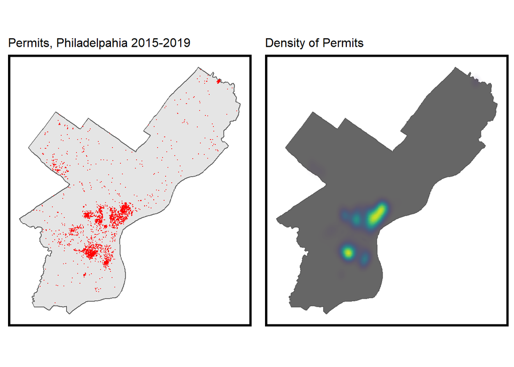

```r
# create the fishnet

# uses grid.arrange to organize independent plots
grid.arrange(ncol=2,
ggplot() +
  geom_sf(data = boundary) +
  geom_sf(data = permits, colour="red", size=0.1, show.legend = "point") +
  labs(title= "Permits, Philadelpahia 2015-2019")+
  mapTheme(),
ggplot() +
  geom_sf(data = boundary, fill = "grey40") +
  stat_density2d(data = data.frame(st_coordinates(permits)),
                 aes(X, Y, fill = ..level.., alpha = ..level..),
                 size = 0.01, bins = 40, geom = 'polygon') +
  scale_fill_viridis() +
  scale_alpha(range = c(0.00, 0.35), guide = FALSE) +
  labs(title = "Density of Permits") +
  theme(legend.position = "none")+
  mapTheme())
```

```r
#Fishnet code
fishnet <-
  st_make_grid(boundary,
               cellsize = 500,
               square = TRUE) %>%
  .[boundary] %>%
  st_sf() %>%
  mutate(uniqueID = rownames(.))

permit_net <-
  dplyr::select(permits) %>% #an SF point object
  mutate(countpermits = 1) %>% #giving value of one to each point
  aggregate(., fishnet, sum) %>% #aggregate points. period represents burglaries. sum number of "1" points that fall within each grid cell. aggregate is a type of spatial join. normally would do a join and them summarize, but this does both in one step.
  mutate(countpermits = replace_na(countpermits, 0), #where there weren't any crimes
         uniqueID = rownames(.),#make into a column
         cvID = sample(round(nrow(fishnet) / 24),
                       size=nrow(fishnet), replace = TRUE)) #adding a random number to each grid cell for cross validation later
```

Next, we create a geospatial dataset to help us understand the smooth variation of displacement risk across the city. This key element of our analysis is the “fishnet,” a continuous grid pattern overlay in which every polygon is connected on all sides to the other polygon neighbors. This analysis uses a fishnet with 500x500 foot grid cells. We use a fishnet to treat displacement risk (presence of new construction permits) as a phenomenon that varies continuously across space. We will use the fishnet to aggregate point-level data.

The figure below shows the count of new construction permits across the fishnet. Grid cells shown in yellow have the largest number of permits. These locations are primarily concentrated in the Center City and North East Philadelphia areas.

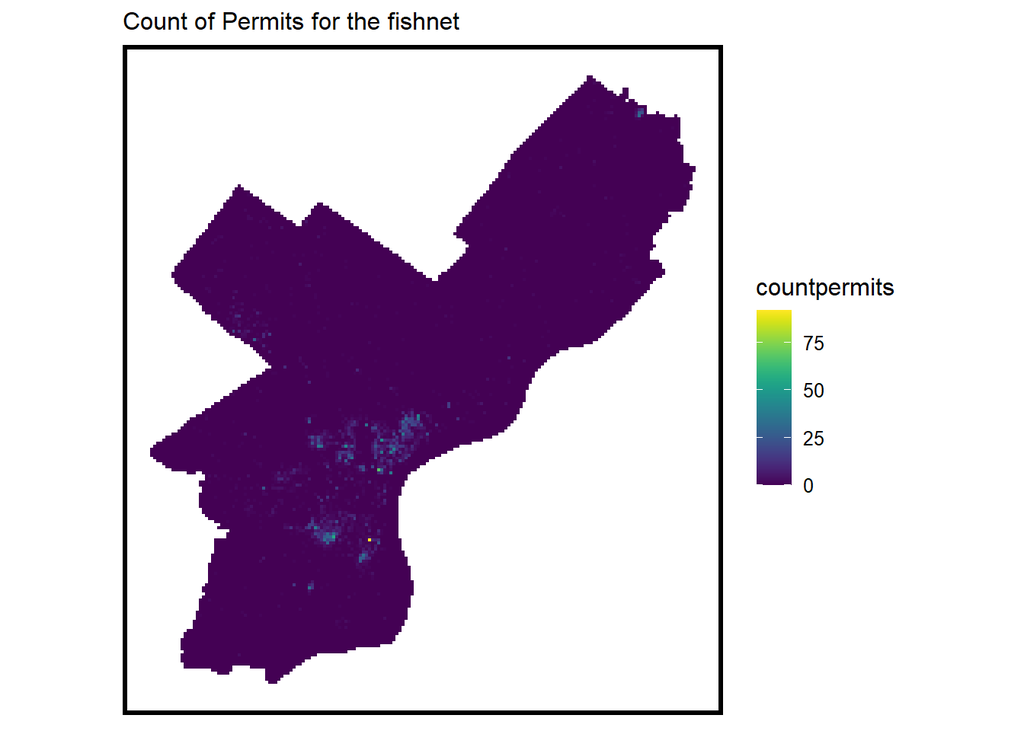

```r
ggplot() +
  geom_sf(data = permit_net, aes(fill = countpermits), color = NA) +
  scale_fill_viridis() +
  labs(title = "Count of Permits for the fishnet") +
  mapTheme()
```

Next we gather data on the boundaries of Philadelphia’s neighborhoods. We will use neighborhood’s as a unit of analysis for both cross-validation of the predictive model and to understand locations of greatest risk.

```r
#nhood <- st_read("/Users/ashabazil/Documents/GitHub/geo-data/Neighborhoods_Philadelphia/Neighborhoods_Philadelphia.geojson") %>%
#st_transform(st_crs(fishnet))

#Should work for both of us using this link
nhood<- st_read("https://raw.githubusercontent.com/azavea/geo-data/2e0c6a9f42d862e39dcee292b851000c973e6de2/Neighborhoods_Philadelphia/Neighborhoods_Philadelphia.geojson") %>%
st_transform(st_crs(fishnet))

#ggplot()+
  #geom_sf(data=nhood)+
  #mapTheme()
```

### Home Value Exploration

To further help us understand neighborhood changes that may lead to displacement risk, we gather data from the Department of Records on [Real Estate Transfers](https://www.opendataphilly.org/dataset/real-estate-transfers). The real estate transfers data shows the dates and location of property sales, deeds, mortgages, and sheriff deeds, and includes associated data, such as any realty transfer tax paid. We gathered data for 2017 and 2018, and calculated the percent change in home value in order to categorize each observation as “No Change”, “Increase in Home Value”, “Decrease in Home Value”, or “No Answer.” Because we are focused on changes in home value (and resulting increases in property taxes) as a primary mechanism for driving displacement, we wish to understand the patterns of changes in home values across the city.

```r
#real estate transfer data
#this takes a while
rt <-
  st_read("https://phl.carto.com/api/v2/sql?q=SELECT+*+FROM+RTT_SUMMARY+WHERE+display_date+>='2017-01-01'+AND+display_date+<=+'2018-12-31'AND+opa_account_num+!=+'NA'&format=geojson&skipfields=cartodb_id") %>%
st_transform('ESRI:102729')

#filter for obs with values
rtt <- rt %>%
    mutate(adjusted_fair_market_value = replace_na(adjusted_fair_market_value, 0), year = substr(display_date,1,4)) %>%
    filter(!(adjusted_fair_market_value == 0)) %>%
    dplyr::select(adjusted_fair_market_value, opa_account_num, year)

#split by year
rtt_17 <- rtt %>%
    filter(year == 2017) %>%
    rename(value_17 = adjusted_fair_market_value) %>%
    filter(value_17<=9878103)

rtt_18 <- rtt %>%
    filter(year == 2018) %>%
    rename(value_18 = adjusted_fair_market_value)


#create difference percent, difference value, and categorical variable
joined<-
  st_join(rtt_17, rtt_18, by = opa_account_num) %>%
  mutate(difference = value_18-value_17,
         dif_cat= case_when(difference == 0 ~ "No Change",
                            difference > 0 ~ "Increase in Home Value",
                            difference < 0 ~ "Decrease in Home Value",
                            # anything that isn't in the above groups (i.e. NA which is No Answer) gets to be No Answer
                            TRUE ~ "No Answer"),
         dif_cat = factor(dif_cat, levels = c("Decrease in Home Value", "Increase in Home Value", "No Change", "No Answer")),
         dif_pct= (difference/value_17)*100) %>%
  filter(!(difference == is.na(.)))

#split by increase and decreased

decreasedHV <-
  joined %>%
  filter(dif_cat == "Decrease in Home Value", dif_pct <= -3) %>%
  mutate(dif_pct= abs(dif_pct))

increasedHV <-
  joined %>%
  filter(dif_cat == "Increase in Home Value")
```

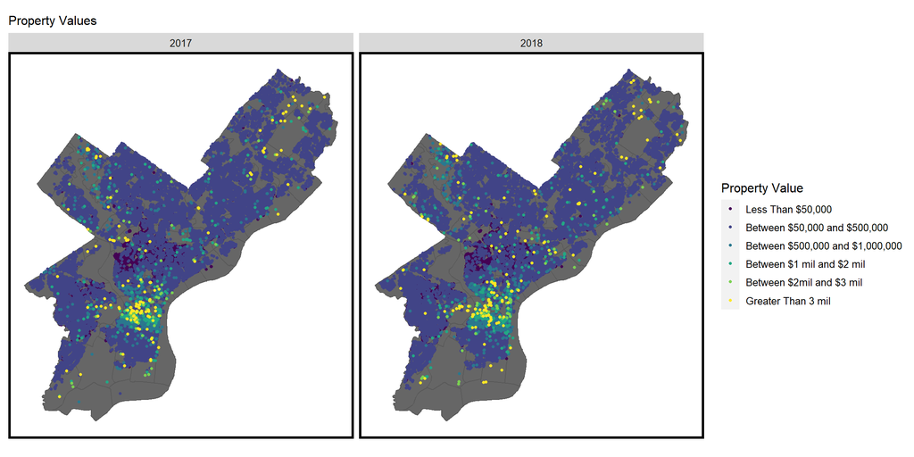

```r
#plot of just property values
rtt_plot<-
  rtt%>%
  filter(year==2018| year == 2017) %>%
  mutate(
         val_cat= case_when(adjusted_fair_market_value >=0 & adjusted_fair_market_value <= 50000 ~ "Less Than $50,000",
                            adjusted_fair_market_value > 50000 & adjusted_fair_market_value<= 500000  ~ "Between $50,000 and $500,000",
                            adjusted_fair_market_value > 500000 & adjusted_fair_market_value<= 1000000  ~ "Between $500,000 and $1,000,000",
                            adjusted_fair_market_value > 1000000 & adjusted_fair_market_value<= 2000000  ~ "Between $1 mil and $2 mil",
                            adjusted_fair_market_value > 2000000 & adjusted_fair_market_value<= 3000000  ~ "Between $2mil and $3 mil",
                            adjusted_fair_market_value > 3000000 ~ "Greater Than 3 mil",
                            TRUE ~ "No Answer"),
         val_cat = factor(val_cat, levels = c("Less Than $50,000", "Between $50,000 and $500,000", "Between $500,000 and $1,000,000", "Between $1 mil and $2 mil", "Between $2mil and $3 mil","Greater Than 3 mil","No Answer")))


ggplot()+
    geom_sf(data = nhood, fill = "grey40") +
    geom_sf(data=rtt_plot, aes(color=val_cat),
            show.legend="point", size=1)+
    scale_color_viridis(discrete = TRUE,
                        #labels=qBr(rtt_plot, "adjusted_fair_market_value"),
                        name="Property Value")+
    facet_wrap(~year)+
    labs(title="Property Values")+
    mapTheme()
```

The figures below depict the increases and decreases in home value between 2017 and 2018 by percentage difference. Locations with greatest increases are generally clustered in the Center City area and locations directly to the north. Locations seeing a decrease in values are more widely scattered across the city, and the percentage difference in magnitudes are substantially smaller than the increased percent difference.

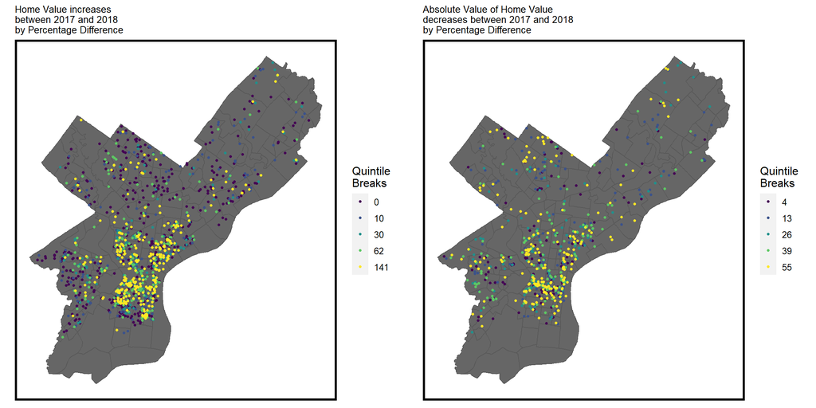

```r
# plot magnitude of percentage increases and decreases
#flip color scale for decrease, filter out small decrease differences

grid.arrange(ncol=2,
  ggplot()+
    geom_sf(data = nhood, fill = "grey40") +
    geom_sf(data=increasedHV, aes(color=q5(dif_pct)),
            show.legend="point", size=1)+
    scale_color_viridis(discrete = TRUE,
                        labels=qBr(increasedHV, "dif_pct"),
                        name="Quintile\nBreaks")+
    labs(title="Home Value increases\nbetween 2017 and 2018\nby Percentage Difference")+
    mapTheme()+theme(plot.title = element_text(size = 10)),

    ggplot()+
    geom_sf(data = nhood, fill = "grey40") +
    geom_sf(data=decreasedHV, aes(color=q5(dif_pct)),
            show.legend="point", size=1)+
    scale_color_viridis(discrete = TRUE,
                        labels=qBr(decreasedHV, "dif_pct"),
                        name="Quintile\nBreaks")+
    labs(title="Absolute Value of Home Value \ndecreases between 2017 and 2018\nby Percentage Difference")+
    mapTheme()+theme(plot.title = element_text(size = 10)))
```

The figures below show the density of locations where home values increased and decreased between 2017 and 2018. Both of these locations are concentrated in the Center City area, with a greater intensity of home value increases in that location.

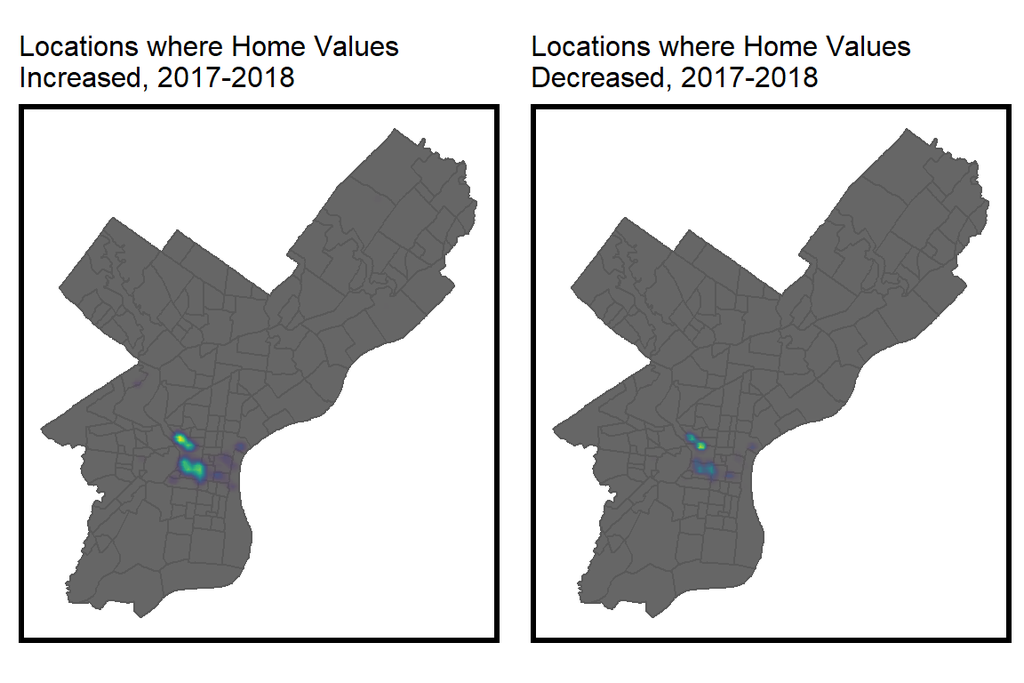

```r
#denisty of homevalues in 2017 and 2018
#does this show density of greatest home values? or density of where there are home values? We have a lot of plots here so not sure if we need these - let me know what you think!

# rt_10 <-
#   st_read("https://phl.carto.com/api/v2/sql?q=SELECT+*+FROM+RTT_SUMMARY+WHERE+display_date+>='2010-01-01'+AND+display_date+<=+'2010-12-31'AND+opa_account_num+!=+'NA'&format=geojson&skipfields=cartodb_id") %>%
# st_transform('ESRI:102729')
#
# #filter for obs with values
# rtt_10 <- rt_10 %>%
#     mutate(adjusted_fair_market_value = replace_na(adjusted_fair_market_value, 0), year = substr(display_date,1,4)) %>%
#     filter(!(adjusted_fair_market_value == 0)) %>%
#     dplyr::select(adjusted_fair_market_value, opa_account_num, year)


# grid.arrange(ncol=2,
# ggplot(rtt_10) +
#   geom_sf(data = nhood, fill = "grey40") +
#   stat_density2d(data = data.frame(st_coordinates(adjusted_fair_market_value)),
#                  aes(X, Y, fill = ..level.., alpha = ..level..),
#                  size = 0.02, bins = 50, geom = 'polygon') +
#   scale_fill_viridis() +
#   scale_alpha(range = c(0.00, 0.50), guide = FALSE) +
#   labs(title = "2010") +
#   theme(legend.position = "none")+
#   mapTheme(),
#
# ggplot(rtt_18) +
#   geom_sf(data = nhood, fill = "grey40") +
#   stat_density2d(data = data.frame(st_coordinates(value_18)),
#                  aes(X, Y, fill = ..level.., alpha = ..level..),
#                  size = 0.01, bins = 40, geom = 'polygon') +
#   scale_fill_viridis() +
#   scale_alpha(range = c(0.00, 0.35), guide = FALSE) +
#   labs(title = "2018") +
#   theme(legend.position = "none")+
#   mapTheme())

#density of change in homevalues based on increasing and decreasing
grid.arrange(ncol=2,
ggplot() +
  geom_sf(data = nhood, fill = "grey40") +
  stat_density2d(data = data.frame(st_coordinates(increasedHV)),
                 aes(X, Y, fill = ..level.., alpha = ..level..),
                 size = 0.02, bins = 50, geom = 'polygon') +
  scale_fill_viridis() +
  scale_alpha(range = c(0.00, 0.50), guide = FALSE) +
  labs(title = "Locations where Home Values \nIncreased, 2017-2018") +
  theme(legend.position = "none")+
  mapTheme(),

ggplot() +
  geom_sf(data = nhood, fill = "grey40") +
  stat_density2d(data = data.frame(st_coordinates(decreasedHV)),
                 aes(X, Y, fill = ..level.., alpha = ..level..),
                 size = 0.01, bins = 40, geom = 'polygon') +
  scale_fill_viridis() +
  scale_alpha(range = c(0.00, 0.35), guide = FALSE) +
  labs(title = "Locations where Home Values \nDecreased, 2017-2018") +
  theme(legend.position = "none")+
  mapTheme())
```

### 311 and Census Data

We also gathered data on [311 Service and Information Requests](https://www.opendataphilly.org/dataset/311-service-and-information-requests) to included in our predictive model. These data represents all service and information requests submitted to the Philly311 via the 311 mobile application, calls, walk-ins, emails, the 311 website, or social media. From the 311 data, we gathered data from 2015 to 2019 on locations of Sanitation & Dumpster Violations, locations of Dangerous Building Reports, and locations of Vacant Lot Reports. We use these data as variables in the model to help predict locations of residential building permits.

The figures below show the density of locations of these reports and violations, which are distributed across the city.

```r
#https://cityofphiladelphia.github.io/carto-api-explorer/#public_cases_fc

# Sanitation Data
sanitation<-
  st_read("https://phl.carto.com/api/v2/sql?q=SELECT+*+FROM+public_cases_fc+WHERE+service_name+=+'Sanitation+/+Dumpster+Violation'OR+service_name+=+'Illegal+Dumping'+AND+requested_datetime+>=+'2015-01-01'+AND+requested_datetime+<+'2019-12-31'&filename=sanitation&format=geojson&skipfields=cartodb_id") %>%
    mutate(year = substr(requested_datetime,1,4)) %>%
    #filter(year %in% c("2020")) %>%
    dplyr::select(Y = lat, X = lon) %>%
    na.omit() %>%
    st_as_sf(coords = c("X", "Y"), crs = 4326, agr = "constant") %>%
    st_transform(st_crs(fishnet)) %>%
    mutate(Legend = "Sanitation")

# Service Data
service<-
  st_read("https://phl.carto.com/api/v2/sql?q=SELECT+*+FROM+public_cases_fc+WHERE+service_name+=+'Building+Dangerous'+AND+requested_datetime+>=+'2015-01-01'+AND+requested_datetime+<+'2019-12-31'&filename=service&format=geojson&skipfields=cartodb_id") %>%
    mutate(year = substr(requested_datetime,1,4)) %>%
    dplyr::select(Y = lat, X = lon) %>%
    na.omit() %>%
    st_as_sf(coords = c("X", "Y"), crs = 4326, agr = "constant") %>%
    st_transform(st_crs(fishnet)) %>%
    mutate(Legend = "Service")


# Vacant Lot Data
vacant<-
  st_read("https://phl.carto.com/api/v2/sql?q=SELECT+*+FROM+public_cases_fc+WHERE+service_name+=+'Vacant+House+or+Commercial'+AND+requested_datetime+>=+'2015-01-01'+AND+requested_datetime+<+'2019-12-31'&filename=vacant&format=geojson&skipfields=cartodb_id") %>%
    mutate(year = substr(requested_datetime,1,4)) %>%
    dplyr::select(Y = lat, X = lon) %>%
    na.omit() %>%
    st_as_sf(coords = c("X", "Y"), crs = 4326, agr = "constant") %>%
    st_transform(st_crs(fishnet)) %>%
    mutate(Legend = "Vacant")
```

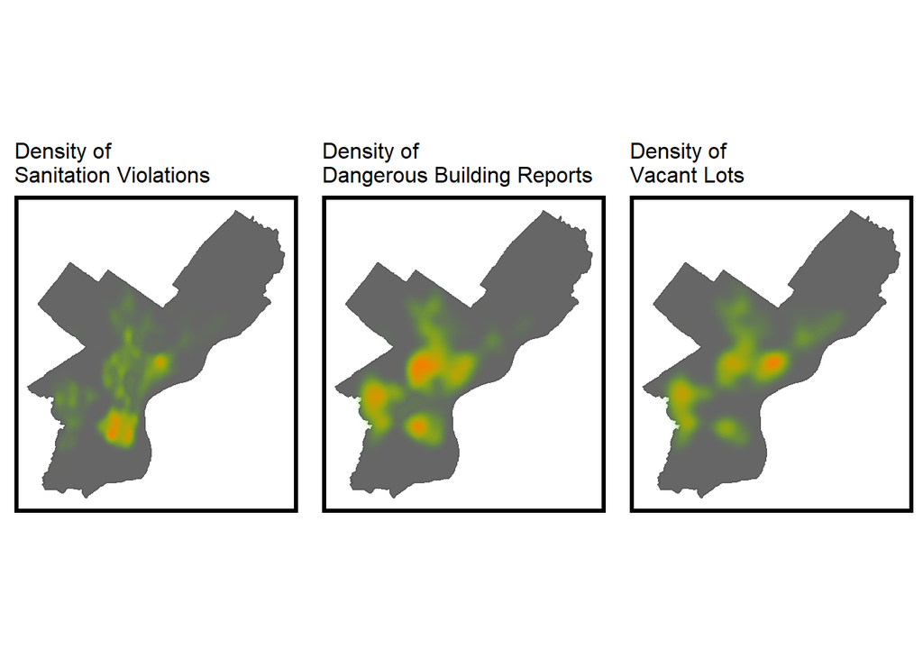

```r
grid.arrange(ncol = 3,
  ggplot() + geom_sf(data = boundary, fill = "grey40") +
      stat_density2d(data = data.frame(st_coordinates(sanitation)),
                 aes(X, Y, fill = ..level.., alpha = ..level..),
                 size = 0.01, bins = 40, geom = 'polygon') +
      scale_fill_gradient(low = "#25CB10", high = "#FA7800", name = "Density") +
      scale_alpha(range = c(0.00, 0.35), guide = FALSE) +
      labs(title = "Density of \nSanitation Violations") +
      mapTheme()+
      theme(legend.position = "none"),
  ggplot() + geom_sf(data = boundary, fill = "grey40") +
      stat_density2d(data = data.frame(st_coordinates(service)),
                 aes(X, Y, fill = ..level.., alpha = ..level..),
                 size = 0.01, bins = 40, geom = 'polygon') +
      scale_fill_gradient(low = "#25CB10", high = "#FA7800", name = "Density") +
      scale_alpha(range = c(0.00, 0.35), guide = FALSE) +
      labs(title = "Density of \nDangerous Building Reports") +
      mapTheme()+
      theme(legend.position = "none"),
  ggplot() + geom_sf(data = boundary, fill = "grey40") +
      stat_density2d(data = data.frame(st_coordinates(vacant)),
                 aes(X, Y, fill = ..level.., alpha = ..level..),
                 size = 0.01, bins = 40, geom = 'polygon') +
      scale_fill_gradient(low = "#25CB10", high = "#FA7800", name = "Density") +
      scale_alpha(range = c(0.00, 0.35), guide = FALSE) +
      labs(title = "Density of \nVacant Lots") +
      mapTheme()+
      theme(legend.position = "none"))
```

Finally, we gathered data from the U.S. Census Bureau 2018 5-year American Community Survey (ACS) at the census tract level on median household income, education level, and moving dates. We used these data to calculate the following variables for inclusion in the predictive model:

- Percent of Voting Age Population with the following Education levels:
  - No High School Degree
  - High School Degree
  - Some College Education
  - Associate’s Degree
  - Bachelor’s Degree
  - Graduate or Professional Degree
- Percent of Residents in Owner-Occupied Housing
- Percent of Residents in Renter-Occupied Housing
- Percent of Residents who Moved into Owner-Occupied Housing:
  - Before 2010
  - 2010 to 2014
  - 2015 to 2018
- Percent of Residents who Moved into Renter-Occupied Housing:
  - Before 2010
  - 2010 to 2014
  - 2015 to 2018

As described in further detail below, we used a selection of these variables within our predictive model as indicators of residential building permit locations.

```r
census_api_key("337be6633f769979b1dfc56e5071279d780c2090", overwrite = TRUE)

dd18_5 <- load_variables(year = 2018, dataset = "acs5", cache = TRUE)

variables=c(Median_HHInc="B19013_001",
            VotingAgePop="B29002_001", #CITIZEN, VOTING-AGE POPULATION BY EDUCATIONAL ATTAINMENT: TOTAL
            HS_LessThan9Grade="B29002_002", #CITIZEN, VOTING-AGE POPULATION BY EDUCATIONAL ATTAINMENT: Less than 9th grade
            HS_9to12Grade="B29002_003", #CITIZEN, VOTING-AGE POPULATION BY EDUCATIONAL ATTAINMENT: 9th to 12th grade, no diploma
            HS="B29002_004", #CITIZEN, VOTING-AGE POPULATION BY EDUCATIONAL ATTAINMENT: High school graduate (includes equivalency)
            SomeCollege="B29002_005", #CITIZEN, VOTING-AGE POPULATION BY EDUCATIONAL ATTAINMENT: Some college, no degree
            Associate="B29002_006", #CITIZEN, VOTING-AGE POPULATION BY EDUCATIONAL ATTAINMENT: Associate's degree
            Bach="B29002_007", #CITIZEN, VOTING-AGE POPULATION BY EDUCATIONAL ATTAINMENT: Bachelor's degree
            GradProf="B29002_008", #CITIZEN, VOTING-AGE POPULATION BY EDUCATIONAL ATTAINMENT: Graduate or professional degree
            Pop_occHousing="B25026_001", #Total population in occupied housing units
            Pop_OwnOcc="B25026_002", #Total population in occupied housing units!!Owner occupied
            Pop_Own2017later="B25026_003", #Total population in occupied housing units!!Owner occupied!!Moved in 2017 or later
            Pop_Own2015to2016="B25026_004", #Total population in occupied housing units!!Owner occupied!!Moved in 2015 to 2016
            Pop_Own2010to2014="B25026_005", #Total population in occupied housing units!!Owner occupied!!Moved in 2010 to 2014
            Pop_Own2000to2009="B25026_006", #Total population in occupied housing units!!Owner occupied!!Moved in 2000 to 2009
            Pop_Own1990to1999="B25026_007", #Total population in occupied housing units!!Owner occupied!!Moved in 1990 to 1999
            Pop_Own1989earlier="B25026_008", #Total population in occupied housing units!!Owner occupied!!Moved in 1989 or earlier
            Pop_RentOcc="B25026_009", #Total population in occupied housing units!!Renter occupied
            Pop_Rent2017later="B25026_010", #Total population in occupied housing units!!Renter occupied!!Moved in 2017 or later
            Pop_Rent2015to2016="B25026_011", #Total population in occupied housing units!!Renter occupied!!Moved in 2015 to 2016
            Pop_Rent2010to2014="B25026_012", #Total population in occupied housing units!!Renter occupied!!Moved in 2010 to 2014
            Pop_Rent2000to2009="B25026_013", #Total population in occupied housing units!!Renter occupied!!Moved in 2000 to 2009
            Pop_Rent1990to1999="B25026_014", #Total population in occupied housing units!!Renter occupied!!Moved in 1990 to 1999
            Pop_Rent1989earlier="B25026_015") #Total population in occupied housing units!!Renter occupied!!Moved in 1989 or earlier

ACS_2018 <- get_acs(geography = "tract",
                           state = 42,
                           county= 101,
                           variables = variables,
                           year = 2018,
                           geometry=T)%>%
  st_transform('ESRI:102729')  %>%
  dplyr::select(variable, estimate, GEOID) %>%
  spread(variable, estimate) %>%
  mutate(percent_NoHS= ifelse(VotingAgePop>0,((HS_LessThan9Grade+HS_9to12Grade) / VotingAgePop),0),
         percent_HS= ifelse(VotingAgePop>0, HS/ VotingAgePop,0),
         percent_SomeCollege= ifelse(VotingAgePop>0,SomeCollege / VotingAgePop,0),
         percent_assoc = ifelse(VotingAgePop>0,Associate / VotingAgePop,0),
         percent_bach = ifelse(VotingAgePop>0,Bach / VotingAgePop,0),
         percent_GradProf = ifelse(VotingAgePop>0,GradProf / VotingAgePop,0),
         percent_ownOcc= ifelse(Pop_occHousing>0,Pop_OwnOcc / Pop_occHousing,0),
         percent_rentOcc = ifelse(Pop_occHousing>0,Pop_RentOcc / Pop_occHousing,0),
         percent_Own_Pre2010 = ifelse(Pop_occHousing>0,
                                      ((Pop_Own1989earlier + Pop_Own1990to1999 + Pop_Own2000to2009) / Pop_occHousing),0),
         percent_Own_2010to2014 = ifelse(Pop_occHousing>0,Pop_Own2010to2014 / Pop_occHousing,0),
         percent_Own_2015to2018 = ifelse(Pop_occHousing>0,((Pop_Own2015to2016 + Pop_Own2017later) / Pop_occHousing),0),
         percent_Rent_Pre2010 = ifelse(Pop_occHousing>0,
                                       ((Pop_Rent1989earlier + Pop_Rent1990to1999 + Pop_Rent2000to2009) / Pop_occHousing),0),
         percent_Rent_2010to2014 = ifelse(Pop_occHousing>0,Pop_Rent2010to2014 / Pop_occHousing,0),
         percent_Rent_2015to2018 = ifelse(Pop_occHousing>0,
                                          ((Pop_Rent2015to2016 + Pop_Rent2017later) / Pop_occHousing),0))%>%
 dplyr::select(Median_HHInc, percent_NoHS, percent_HS, percent_SomeCollege, percent_assoc, percent_bach, percent_GradProf,
         percent_ownOcc, percent_rentOcc, percent_Own_Pre2010, percent_Own_2010to2014, percent_Own_2015to2018,
         percent_Rent_Pre2010, percent_Rent_2010to2014,   percent_Rent_2015to2018)%>%
  mutate(Median_HHInc = replace_na(Median_HHInc, 0),
         percent_NoHS = replace_na(percent_NoHS,0),
         percent_HS= replace_na(percent_HS,0),
         percent_SomeCollege= replace_na(percent_SomeCollege,0),
         percent_assoc= replace_na(percent_assoc,0),
         percent_bach= replace_na(percent_bach,0),
         percent_GradProf= replace_na(percent_GradProf,0),
         percent_ownOcc= replace_na(percent_ownOcc,0),
         percent_rentOcc= replace_na(percent_rentOcc,0),
         percent_Own_Pre2010= replace_na(percent_Own_Pre2010,0),
         percent_Own_2010to2014= replace_na(percent_Own_2010to2014,0),
         percent_Own_2015to2018= replace_na(percent_Own_2015to2018,0),
         percent_Rent_Pre2010= replace_na(percent_Rent_Pre2010,0),
         percent_Rent_2010to2014= replace_na(percent_Rent_2010to2014,0),
         percent_Rent_2015to2018= replace_na(percent_Rent_2015to2018,0))
```

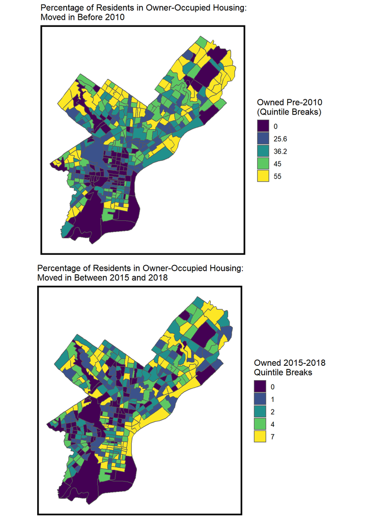

```r
ACS_2018_plot<-
  ACS_2018%>%
  mutate(percent_Own_Pre2010_per=percent_Own_Pre2010*100)%>%
  mutate(percent_Own_2015to2018_per=percent_Own_2015to2018*100)%>%
  mutate(percent_Rent_2015to2018_per=percent_Rent_2015to2018*100)

grid.arrange(nrow=2,
ggplot()+
  geom_sf(data=ACS_2018_plot, aes(fill=q5(percent_Own_Pre2010_per)))+
  scale_fill_viridis(discrete = TRUE,
                    labels = qBr(ACS_2018_plot, "percent_Own_Pre2010_per"),
                    name = "Owned Pre-2010\n(Quintile Breaks)") +
  labs(title = "Percentage of Residents in Owner-Occupied Housing: \nMoved in Before 2010") +
  mapTheme(),
ggplot()+
  geom_sf(data=ACS_2018_plot, aes(fill=q5(percent_Own_2015to2018_per)))+
  scale_fill_viridis(discrete = TRUE,
                    labels = qBr(ACS_2018_plot, "percent_Own_2015to2018_per"),
                    name = "Owned 2015-2018\nQuintile Breaks") +
  labs(title = "Percentage of Residents in Owner-Occupied Housing: \nMoved in Between 2015 and 2018") +
  mapTheme()
)
```

### Data Wrangling

After collecting the variety of data described above to serve as indicators of residential permits, we aggregated all data to our previously created fishnet. For point data (e.g., sanitation violations, vacant lot locations), we count the number of incidents within each grid cell. For census data (e.g., median household income), we join the census data values from the census tract where the centroid of each grid cell is located.

```r
#put other data into fishnet.
vars_net <-
  rbind(sanitation, service, vacant) %>%
  st_join(., fishnet, join=st_within) %>% #if point is within this polygon, assign the polygon id to this point. then get it into the unit of grid polygons
  st_drop_geometry() %>%
  group_by(uniqueID, Legend) %>% #group by unique id and the type of variable, in this case just one cars
  summarize(count = n()) %>% #counting each point per grid cell
  full_join(fishnet, by = "uniqueID") %>%
  spread(Legend, count, fill=0) %>%
  st_sf() %>%
  dplyr::select(-`<NA>`) %>%
  na.omit() %>%
  ungroup()
```

```r
vars_net<-
  vars_net%>%
  st_centroid()%>%
  st_join(ACS_2018)%>%
  na.omit()
```

## Spatial Processes

As we attempt to predict construction permits across space, it is important to account for the spatial process involved in the clustering of construction permits. In this section we will explain the features we create as a means of accounting for spatial clustering.

### Nearest Neighbor Prediction Factors by Fishnet

Next we create average nearest neighbor features for each point-levek risk factor (sanitation reports, service requests, and vacant lots) by converting the grid cells to centroid points and then measuring the distance to 3 risk factor points. This better accounts for the relative distance to our point risk factors compared to the alternative of simply summing the factors by grid cell.

```r
nn_function <- function(measureFrom,measureTo,k) {
  measureFrom_Matrix <-
    as.matrix(measureFrom)
  measureTo_Matrix <-
    as.matrix(measureTo)
  nn <-
    get.knnx(measureTo, measureFrom, k)$nn.dist
    output <-
      as.data.frame(nn) %>%
      rownames_to_column(var = "thisPoint") %>%
      gather(points, point_distance, V1:ncol(.)) %>%
      arrange(as.numeric(thisPoint)) %>%
      group_by(thisPoint) %>%
      summarize(pointDistance = mean(point_distance)) %>%
      arrange(as.numeric(thisPoint)) %>%
      dplyr::select(-thisPoint) %>%
      pull()

  return(output)
}
```

```r
st_c <- st_coordinates
st_coid <- st_centroid

vars_net <-
  vars_net %>%
    mutate(
      Sanitation.nn =
        nn_function(st_c(st_coid(vars_net)), st_c(sanitation),3),
      Service.nn =
        nn_function(st_c(st_coid(vars_net)), st_c(service),3),
      Vacant.nn =
        nn_function(st_c(st_coid(vars_net)), st_c(vacant),3))
```

### Creating Distance to Center City as a Variable

We next calculate the distance to downtown Philadelphia (Center City) and add the risk factor to the fishnet. We believe this serves to reflect the effect of proximity to the central business and growth hub of the city.

```r
ccPoint <-
  filter(nhood, name == "CENTER_CITY") %>%
  st_centroid()

vars_net$ccDistance =
  st_distance(st_centroid(vars_net),ccPoint) %>%
  as.numeric()
```

### Variable Plots

The figures below depict a selection of risk factors mapped to the fishnet. The variety of spatial distributions across these maps indicate that the risk factors illustrate different spatial processes. For example, locations with high concentrations of residents with a Bachelor’s degree are concentrated in the Center City and Northwest Philadelphia areas, while distance to the nearest three sanitation violations are distributed roughly evenly across the city.

[figure not shown]

```r
grid.arrange(ncol=2,
  ggplot()+
    geom_sf(data=vars_net, aes(color=Median_HHInc))+
    scale_color_viridis()+
    labs(title="Median Household Income")+
    mapTheme()+theme(plot.title = element_text(size = 10), legend.title=element_blank()),
  ggplot()+
    geom_sf(data=vars_net, aes(color=percent_HS))+
    scale_color_viridis()+
    labs(title="Voting-Age Pop % No High School")+
    mapTheme()+theme(plot.title = element_text(size = 10), legend.title=element_blank()),
  ggplot()+
    geom_sf(data=vars_net, aes(color=percent_bach))+
    scale_color_viridis()+
    labs(title="Voting-Age Pop % Bachelors")+
    mapTheme()+theme(plot.title = element_text(size = 10), legend.title=element_blank()),
  ggplot()+
    geom_sf(data=vars_net, aes(color=percent_ownOcc))+
    scale_color_viridis()+
    labs(title="Pop % in Owner-Occ Housing")+
    mapTheme()+theme(plot.title = element_text(size = 10), legend.title=element_blank()),
  ggplot()+
    geom_sf(data=vars_net, aes(color=percent_Own_Pre2010))+
    scale_color_viridis()+
    labs(title="Pop % in Owner-Occ \nSince Pre-2010")+
    mapTheme()+theme(plot.title = element_text(size = 10), legend.title=element_blank()),
  ggplot()+
    geom_sf(data=vars_net, aes(color=percent_Own_2015to2018))+
    scale_color_viridis()+
    labs(title="Pop % in Owner-Occ \nSince 2015-2018")+
    mapTheme()+theme(plot.title = element_text(size = 10), legend.title=element_blank()),
  ggplot()+
    geom_sf(data=vars_net, aes(color=percent_Rent_Pre2010))+
    scale_color_viridis()+
    labs(title="Pop % in Renter-Occ \nSince Pre-2010")+
    mapTheme()+theme(plot.title = element_text(size = 10), legend.title=element_blank()),
  ggplot()+
    geom_sf(data=vars_net, aes(color=percent_Own_2015to2018))+
    scale_color_viridis()+
    labs(title="Pop % in Renter-Occ \nSince 2015-2018")+
    mapTheme()+theme(plot.title = element_text(size = 10), legend.title=element_blank()),
  ggplot()+
    geom_sf(data=vars_net, aes(color=Sanitation.nn))+
    scale_color_viridis()+
    labs(title="Distance to Nearest 3 \nSaniation Violations")+
    mapTheme()+theme(plot.title = element_text(size = 10), legend.title=element_blank()),
  ggplot()+
    geom_sf(data=vars_net, aes(color=Service.nn))+
    scale_color_viridis()+
    labs(title="Distance to Nearest 3 \nService Requests")+
    mapTheme()+theme(plot.title = element_text(size = 10), legend.title=element_blank()),
  ggplot()+
    geom_sf(data=vars_net, aes(color=Vacant.nn))+
    scale_color_viridis()+
    labs(title="Distance to Nearest 3 \nVacant Lots")+
    mapTheme()+theme(plot.title = element_text(size = 10), legend.title=element_blank()),
  ggplot()+
    geom_sf(data=vars_net, aes(color=ccDistance))+
    scale_color_viridis()+
    labs(title="Distance to \nCenter City")+
    mapTheme()+theme(plot.title = element_text(size = 10), legend.title=element_blank()))
```

### Create Final Net

Finally, we perform a join to combine the permit data with the risk factor data and join neighborhoods to the final net.

```r
## important to drop the geometry from joining features
final_net <-
  left_join(permit_net, st_drop_geometry(vars_net), by="uniqueID")
```

```r
#polygon to polygon joins are hard.

final_net <-
  st_centroid(final_net) %>% #take the centroid of the fishnet
    st_join(dplyr::select(nhood, name), by = "uniqueID") %>% #spatially join those withinthe nhood polygons nd polict districs. ie assign the neighborhood to the fishnet id for whichever nhood the fishnet centroid falls into
    #st_join(dplyr::select(policeDistricts, District), by = "uniqueID") %>%
      st_drop_geometry() %>%
      left_join(dplyr::select(final_net, geometry, uniqueID)) %>%  #get the fishnet back in to get the polygons. drop the geom to do the left join and then being it back in
      st_sf() %>%
  na.omit()

# for live demo
# mapview::mapview(final_net, zcol = "District")
```

## Modeling Approach

We use a geospatial risk model where the dependent variable is new construction permits. We work to predict the risk of new construction permits in particular areas of the city.

### Plots of Local Moran’s I for Fishnet Grid Cells

The success of our model is dependent on its ability to account for spatial clustering at multiple scales. Here we use Local Moran’s I to explore the local spatial process. The null hypothesis is that the count of new construction permits is randomly distributed relative to its immediate neighbors.

We use a nearest neighbor weights matrix to relate a unit (here a fishnet grid) to its eight adjacent neighbors ( this is called a queen continuity).

```r
## generates warnings from PROJ issues
## {spdep} to make polygon to neighborhoods...
final_net.nb <- poly2nb(as_Spatial(final_net), queen=TRUE) #polygons into neighborhood which gives us list of weights for which neighbors it has. creting a netowkr graph of one grid to all others.
## ... and neighborhoods to list of weigths
final_net.weights <- nb2listw(final_net.nb, style="W", zero.policy=TRUE)
```

The inputs of the Local Moran test are the count of new construction permits and the spatial weights matrix. We combine the results of our Local Moran test with the final net and map a few useful test statistics - the Local Morans I value, the p-value, and significant hotspots. We determine the significant hotspots as grid cells that have higher local counts than could be expected under randomness – defined here as a p-value less than 0.00001. By using a smaller p-value to define a significant spot, we get a clear picture of a few intense new construction permit hotspots – notably in Center City and in northeast Philadelphia near the Fishtown neighborhood.

With the Local Moran’s I test, we reject the null hypothesis that the permit count at a given location is randomly distributed relative to it’s immediate neighbors. That is, we can test for (and control for) the spatial autocorrelation of the model errors at the local level.

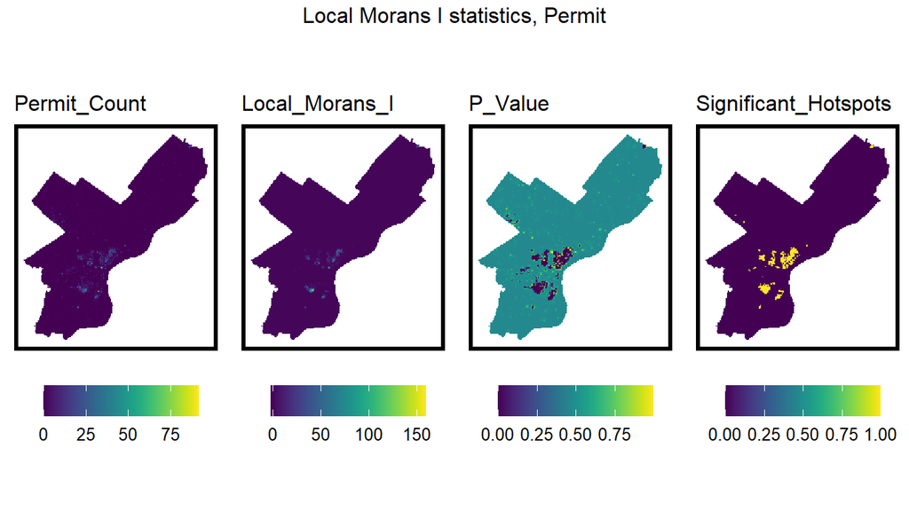

```r
final_net.localMorans <-
  cbind(
    as.data.frame(localmoran(final_net$countpermits, final_net.weights)),
    as.data.frame(final_net)) %>%
    st_sf() %>%
      dplyr::select(Permit_Count = countpermits,
                    Local_Morans_I = Ii,
                    P_Value = `Pr(z > 0)`) %>%
      mutate(Significant_Hotspots = ifelse(P_Value <= 0.00001, 1, 0)) %>%
      gather(Variable, Value, -geometry)

vars <- unique(final_net.localMorans$Variable)
varList <- list()

for(i in vars){
  varList[[i]] <-
    ggplot() +
      geom_sf(data = filter(final_net.localMorans, Variable == i),
              aes(fill = Value), colour=NA) +
      scale_fill_viridis(name="") +
      labs(title=i) +
      mapTheme() + theme(legend.position="bottom")}

do.call(grid.arrange,c(varList, ncol = 4, top = "Local Morans I statistics, Permit"))
```

### Distance to Hot Spots

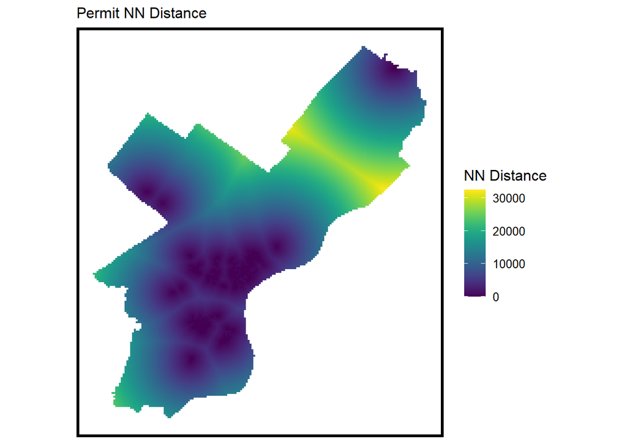

```r
# generates warning from NN
# final_net <- final_net %>%
#   mutate(abandoned.isSig =
#            ifelse(local_morans[,5] <= 0.001, 1, 0)) %>% #how close each grid cell is to a sig hotspot
#   mutate(abandoned.isSig.dist =
#            nn_function(st_c(st_coid(final_net)),
#                        st_c(st_coid(filter(final_net, abandoned.isSig == 1))),
#                        k = 1))

final_net <-
  final_net %>%
  mutate(permit.isSig =
           ifelse(localmoran(final_net$countpermits,
                             final_net.weights)[,5] <= 0.0000001, 1, 0)) %>% #does this need to changed?
  mutate(permit.isSig.dist =
           nn_function(st_coordinates(st_centroid(final_net)),
                       st_coordinates(st_centroid(
                         filter(final_net, permit.isSig == 1))), 1))

ggplot() +
      geom_sf(data = final_net, aes(fill=permit.isSig.dist), colour=NA) +
      scale_fill_viridis(name="NN Distance") +
      labs(title="Permit NN Distance") +
      mapTheme()
```

```r
## What does k = 1 represent? the distance to my closest significant hot spot. Want the biggest number when we're close to a hot spot. Exposure to closest one.  Can we plot this?
```

### Correlation Plots

From the correlation plot of our numerical variables, we see that this new Distnace to Hotspot variable is negatively correlated with the count of new construction permits. That is, as the distance to a significant hotspot increases, the count of permits decreases.

We also see a positive correlation between the percentage of the population with bachelors degrees and count of new construction permits. This is expected given what is known about the nature of new homeowners in changing neighborhoods, and supports our hypothesis about the potential for displacement given these new construction permits alongside higher education levels.

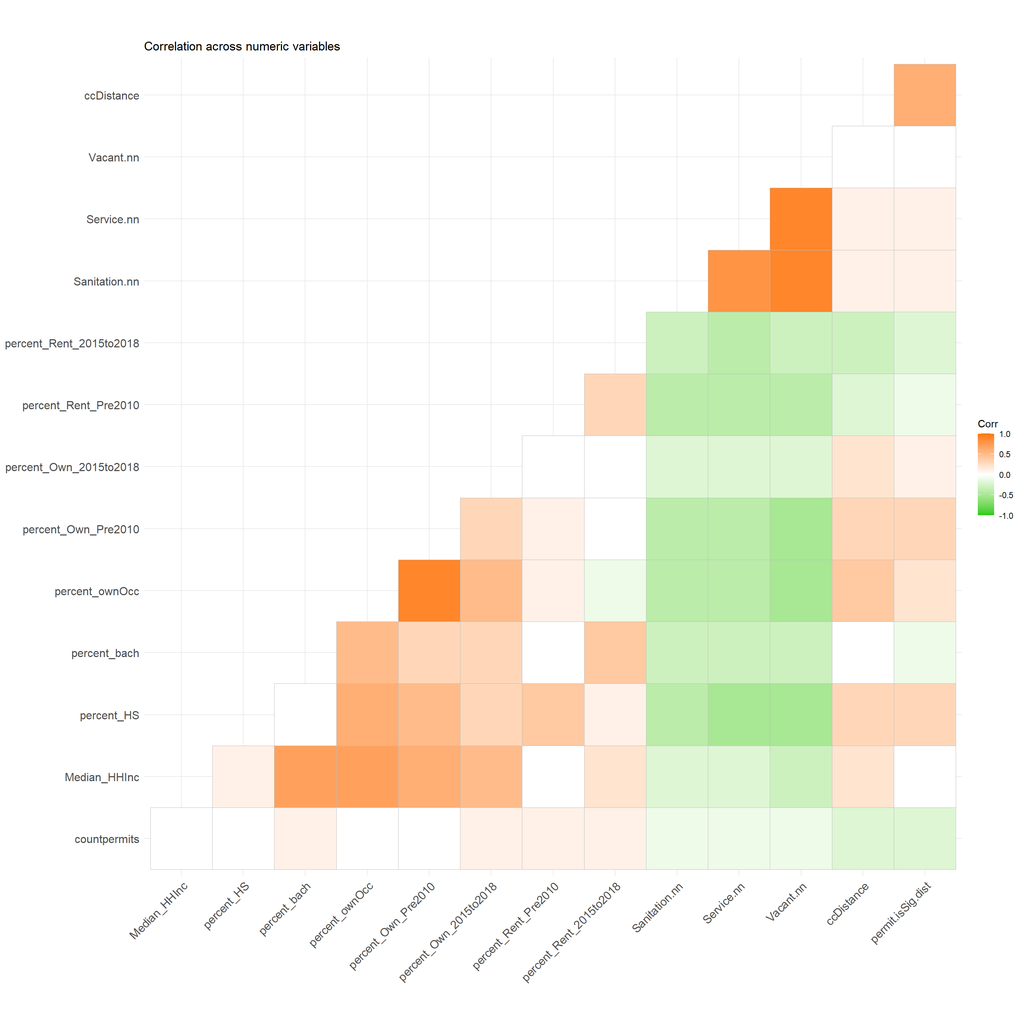

```r
# correlation.long <-
#   st_drop_geometry(final_net) %>%
#     dplyr::select(-uniqueID, -cvID, -name,-ccDistance) %>%
#     gather(Variable, Value, -countpermits)

correlation.long <-
  st_drop_geometry(final_net) %>%
    dplyr::select(.,-Sanitation, -Vacant, -Service, -cvID, -percent_assoc,-percent_Own_2010to2014, -percent_Rent_2010to2014, -percent_NoHS, -percent_SomeCollege,-permit.isSig, -percent_GradProf, -percent_rentOcc, -ccDistance) %>%
    gather(Variable, Value, -countpermits)

# correlation.cor <-
#   correlation.long %>%
#     group_by(Variable) %>%
#     summarize(correlation = cor(Value, countpermits, use = "complete.obs"))
#
# ggplot(correlation.long, aes(Value, countpermits)) +
#   geom_point(size = 0.1) +
#   geom_text(data = correlation.cor, aes(label = paste("r =", round(correlation, 2))),
#             x=-Inf, y=Inf) +
#   geom_smooth(method = "lm", se = FALSE, colour = "black") +
#   facet_wrap(~Variable, ncol = 2, scales = "free") +
#   labs(title = "Permit count as a function of risk factors") +
#   plotTheme()



regVars <-
  #final_net %>%
  select_if(st_drop_geometry(final_net), is.numeric) %>%
  dplyr::select(.,-Sanitation, -Vacant, -Service, -cvID, -percent_assoc,-percent_Own_2010to2014, -percent_Rent_2010to2014, -percent_NoHS, -percent_SomeCollege,-permit.isSig, -percent_GradProf, -percent_rentOcc) %>%
  na.omit()

ggcorrplot(
  round(cor(regVars), 1),
  p.mat = cor_pmat(regVars),
  colors = c("#25CB10", "white", "#FA7800"),
  type="lower",
  insig = "blank") +
    labs(title = "Correlation across numeric variables")
```

```r
# colNameTbl <-
# colnames(regVars)
```

### Regression

Because the count of new construction permits in most grid cells will be quite low (if not zero), we use a linear Poisson regression to best account for the skewed dependent variable distribution.

```r
reg.vars <- c("Sanitation.nn", "Service.nn", "Vacant.nn","ccDistance", "Median_HHInc", "percent_HS", "percent_bach","percent_ownOcc", "percent_Own_Pre2010", "percent_Own_2015to2018","percent_Rent_Pre2010", "percent_Rent_2015to2018")

reg.ss.vars <- c("Sanitation.nn", "Service.nn", "Vacant.nn","ccDistance", "Median_HHInc", "percent_HS", "percent_bach","percent_ownOcc", "percent_Own_Pre2010", "percent_Own_2015to2018","percent_Rent_Pre2010", "percent_Rent_2015to2018","permit.isSig", "permit.isSig.dist")
```

We create two kinds of folds of our data in order to cross-validate - random folds and neighborhood folds.

The LOGO-CV cross validation method iteratively excludes one fold at a time from the model training, and then predicts on that excluded fold. For the neighborhood folds, we assign each grid cell not in that neighborhood to the training set and then test on each grid cell in that neighborhood. This process is repeated until each neighborhood has acted as the hold out. In this way, we ensure that the model training is not affected by the random inclusion or exclusion of an outlier in the training set. However, using neighborhood as the holdout criteria implies an assumption of similarity across neighborhoods in the city, as will be discussed.

```r
crossValidate <- function(dataset, id, dependentVariable, indVariables) {

allPredictions <- data.frame()
cvID_list <- unique(dataset[[id]])

#create test and train folds
for (i in cvID_list) {

  thisFold <- i
  cat("This hold out fold is", thisFold, "\n")

  fold.train <- filter(dataset, dataset[[id]] != thisFold) %>% as.data.frame() %>%
                dplyr::select(id, geometry, indVariables, dependentVariable)
  fold.test  <- filter(dataset, dataset[[id]] == thisFold) %>% as.data.frame() %>%
                dplyr::select(id, geometry, indVariables, dependentVariable)

# regress count of permits on the training fold
  regression <-
    glm(countpermits ~ ., family = "poisson",
      data = fold.train %>%
      dplyr::select(-geometry, -id))

#use regression to predict count of permits
  thisPrediction <-
    mutate(fold.test, Prediction = predict(regression, fold.test, type = "response"))

  allPredictions <-
    rbind(allPredictions, thisPrediction)

  }
  return(st_sf(allPredictions))
}
```

## Cross Validation Methods

We cross validate four different regressions. Two perform random k-fold cross validation - one using the simple risk factors and one adding the distance to significant hotspots variable. Two others perform LOGO-CV based on the neighborhood name - again, one using the simple risk factors and one adding the distance to significant hotspots variable.

```r
reg.cv <- crossValidate(
  dataset = final_net,
  id = "cvID",
  dependentVariable = "countpermits",
  indVariables = reg.vars) %>%
    dplyr::select(cvID = cvID, countpermits, Prediction, geometry)

reg.ss.cv <- crossValidate(
  dataset = final_net,
  id = "cvID",
  dependentVariable = "countpermits",
  indVariables = reg.ss.vars) %>%
    dplyr::select(cvID = cvID, countpermits, Prediction, geometry)

reg.spatialCV <- crossValidate(
  dataset = final_net,
  id = "name",
  dependentVariable = "countpermits",
  indVariables = reg.vars) %>%
    dplyr::select(cvID = name, countpermits, Prediction, geometry)

reg.ss.spatialCV <- crossValidate(
  dataset = final_net,
  id = "name",
  dependentVariable = "countpermits",
  indVariables = reg.ss.vars) %>%
    dplyr::select(cvID = name, countpermits, Prediction, geometry)
```

Each regression error is created by taking the difference between the predicted count of new construction permits and the observed count of construction permits.

```r
reg.summary <-
  rbind(
    mutate(reg.cv,           Error = Prediction - countpermits,
                             Regression = "Random k-fold CV: Just Risk Factors"),

    mutate(reg.ss.cv,        Error = Prediction - countpermits,
                             Regression = "Random k-fold CV: Spatial Process"),

    mutate(reg.spatialCV,    Error = Prediction - countpermits,
                             Regression = "Spatial LOGO-CV: Just Risk Factors"),

    mutate(reg.ss.spatialCV, Error = Prediction - countpermits,
                             Regression = "Spatial LOGO-CV: Spatial Process")) %>%
    st_sf()
```

We visualize the relative performance of each regression by examining the mean average error (MAE) distributions for each fold. The MAE is the absolute value of the mean error.

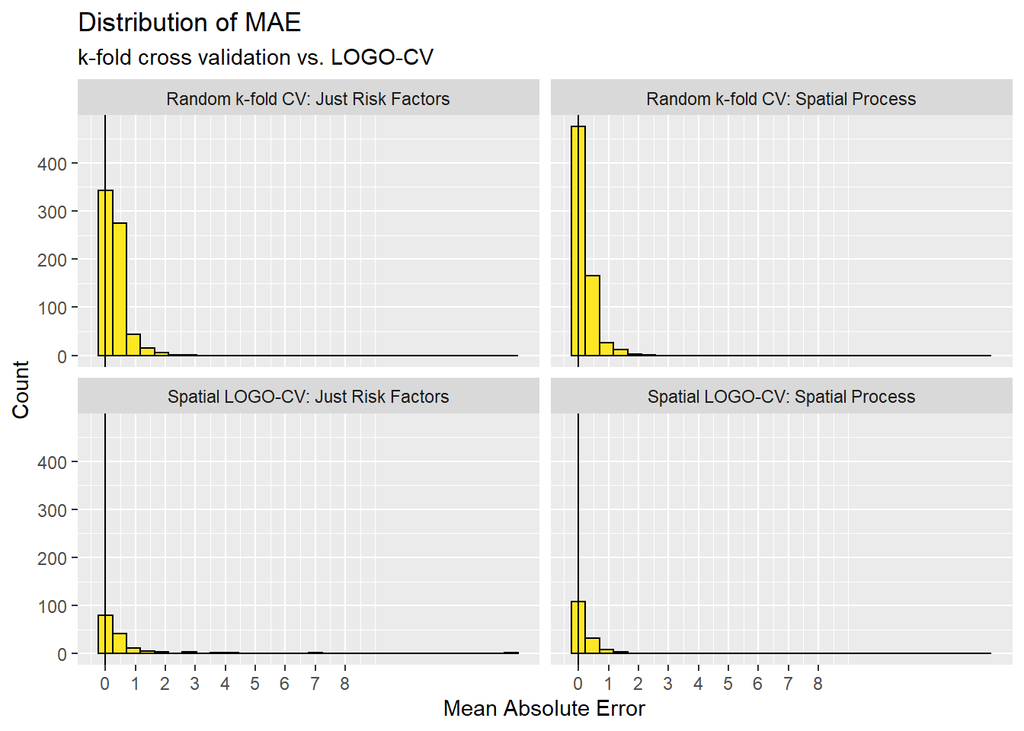

```r
error_by_reg_and_fold <-
  reg.summary %>%
    group_by(Regression, cvID) %>%
    summarize(Mean_Error = mean(Prediction - countpermits, na.rm = T),
              MAE = mean(abs(Mean_Error), na.rm = T),
              SD_MAE = mean(abs(Mean_Error), na.rm = T)) %>%
  ungroup()

error_by_reg_and_fold %>%
  ggplot(aes(MAE)) +
    geom_histogram(bins = 30, colour="black", fill = "#FDE725FF") +
    facet_wrap(~Regression) +
    geom_vline(xintercept = 0) + scale_x_continuous(breaks = seq(0, 8, by = 1)) +
    labs(title="Distribution of MAE", subtitle = "k-fold cross validation vs. LOGO-CV",
         x="Mean Absolute Error", y="Count")
```

We see that the regressions that included the Distance to Hotspot variables (on the right had side of the distribution matrix) had more clustered errors. That is, there were fewer errors of high magnitudes. LOGO-CV assumes that the spatial processes of all other neighborhoods apply to the one hold out, when in actuality that is likely not the case. By using Distance to Hotspot to account for local variability, we improve the models predictive capability particularly in hotspots with high counts of permits. The maps below articulate the reduction in MEA across space that comes from including the spatial process variable as opposed to only risk factors.

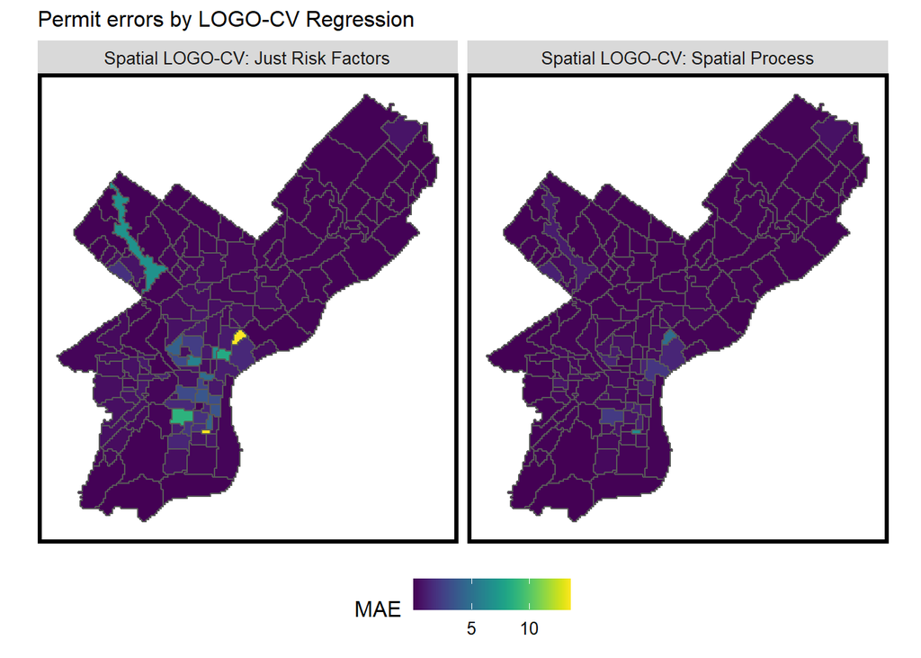

```r
error_by_reg_and_fold %>%
  filter(str_detect(Regression, "LOGO")) %>%
  ggplot() +
    geom_sf(aes(fill = MAE)) +
    facet_wrap(~Regression) +
    scale_fill_viridis() +
    labs(title = "Permit errors by LOGO-CV Regression") +
    mapTheme() + theme(legend.position="bottom")
```

The table of mean MAE and standard deviation of MAE below shows that the random k-fold with spatial processes has the smallest error. The spatial LOGO likely has a higher error because of its assumption that experiences in all other neighborhoods can apply accurately to one.

```r
st_drop_geometry(error_by_reg_and_fold) %>%
  group_by(Regression) %>%
    summarize(Mean_MAE = round(mean(MAE), 2),
              SD_MAE = round(sd(MAE), 2)) %>%
  kable(caption = "MAE by regression") %>%
    kable_styling("striped", full_width = F) %>%
    row_spec(2, color = "black", background = "#FDE725FF") %>%
    row_spec(4, color = "black", background = "#FDE725FF")
```

MAE by regression

| Regression | Mean_MAE | SD_MAE |
| --- | --- | --- |
| Random k-fold CV: Just Risk Factors | 0.33 | 0.34 |
| Random k-fold CV: Spatial Process | 0.22 | 0.28 |
| Spatial LOGO-CV: Just Risk Factors | 0.94 | 2.06 |
| Spatial LOGO-CV: Spatial Process | 0.30 | 0.72 |

```r
#mean(final_net$countpermits)
```

These results are further visualized by examining the MEA by decile of permit counts. The use of the hotspot variable greatly reduced the error in the areas with the highest density of permits.

Still, all models under predicts in high density areas and over predict in low density aras. We could improve this by further engineering spatial features to minimize this discrepency.

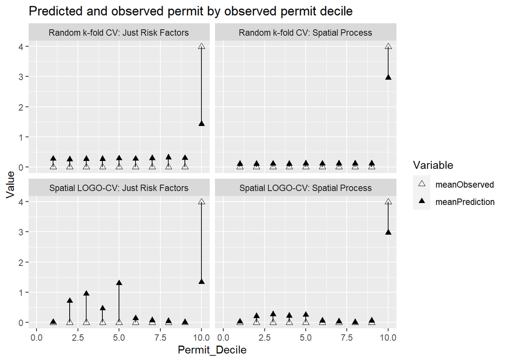

```r
st_drop_geometry(reg.summary) %>%
  group_by(Regression) %>%
    mutate(Permit_Decile = ntile(countpermits, 10)) %>%
  group_by(Regression, Permit_Decile) %>%
    summarize(meanObserved = mean(countpermits, na.rm=T),
              meanPrediction = mean(Prediction, na.rm=T)) %>%
    gather(Variable, Value, -Regression, -Permit_Decile) %>%
    ggplot(aes(Permit_Decile, Value, shape = Variable)) +
      geom_point(size = 2) + geom_path(aes(group = Permit_Decile), colour = "black") +
      scale_shape_manual(values = c(2, 17)) +
      facet_wrap(~Regression) + xlim(0,10) +
      labs(title = "Predicted and observed permit by observed permit decile")
```

### Racial Generalizability

Another important level of generalizability is across social dimensions such as race and income. Below we see a map of the racial context of Philadelphia looking at the distinction between majority white and non white census tracts.

```r
tracts18 <-
  get_acs(geography = "tract", variables = c("B01001_001E","B01001A_001E"),
          year = 2018, state=42, county=101, geometry=T) %>%
  st_transform('ESRI:102729')  %>%
  dplyr::select(variable, estimate, GEOID) %>%
  spread(variable, estimate) %>%
  rename(TotalPop = B01001_001,
         NumberWhites = B01001A_001) %>%
  mutate(percentWhite = NumberWhites / TotalPop,
         raceContext = ifelse(percentWhite > .5, "Majority_White", "Majority_Non_White")) %>%
  .[nhood,]
```

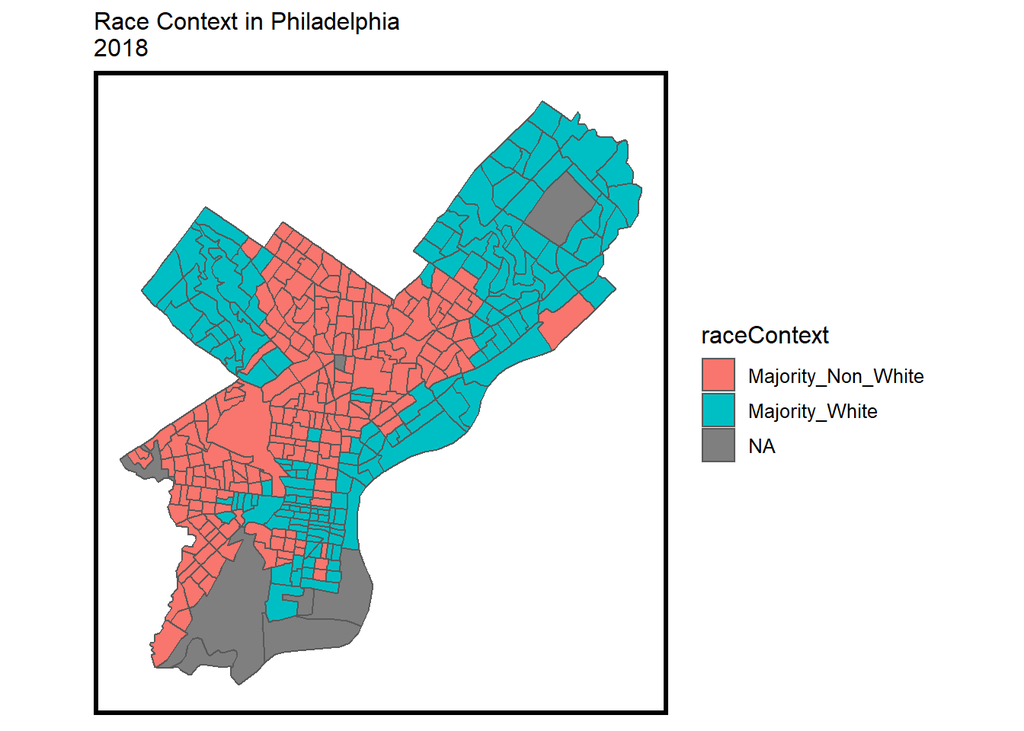

```r
   ggplot()+
    geom_sf(data=tracts18, aes(fill=raceContext))+
    #scale_color_viridis()+
    labs(title="Race Context in Philadelphia\n2018")+
    mapTheme()
```

If we split the mean error by racial context, we see that while the inclusion of the spatial process reduces the magnitude of errors for both non-white and white neighborhoods, it under predicts the risk of new construction permits in non-white areas and over predicts in white areas. This is concerning, and means that any decision makers looking to use the predictions of this model should be aware of this tendency to under predict risk in majority non-white neighborhoods. This under prediction is problematic as it might reduce the amount of resources and support given to non-white neighborhoods due to an incorrectly lower risk prediction. We hope to improve this model’s generalizabilty across race in future iterations of the analysis to minimize this potetial exacerbation of resource inequities.

```r
reg.summary %>%
  filter(str_detect(Regression, "LOGO")) %>%
    st_centroid() %>%
    st_join(tracts18) %>%
    na.omit() %>%
      st_drop_geometry() %>%
      group_by(Regression, raceContext) %>%
      summarize(mean.Error = mean(Error, na.rm = T)) %>%
      spread(raceContext, mean.Error) %>%
      kable(caption = "Mean Error by neighborhood racial context") %>%
        kable_styling("striped", full_width = F)
```

Mean Error by neighborhood racial context

| Regression | Majority_Non_White | Majority_White |
| --- | --- | --- |
| Spatial LOGO-CV: Just Risk Factors | 0.0451183 | 0.1985543 |
| Spatial LOGO-CV: Spatial Process | -0.0143653 | 0.0391116 |

## Risk Map and Results

This model is able to predict the relative risk of new construction permits, and thus risk of displacement, across Philadelphia. In the map below we see the highest risk areas in dark purple, most often surrounded by areas in the second highest risk category.

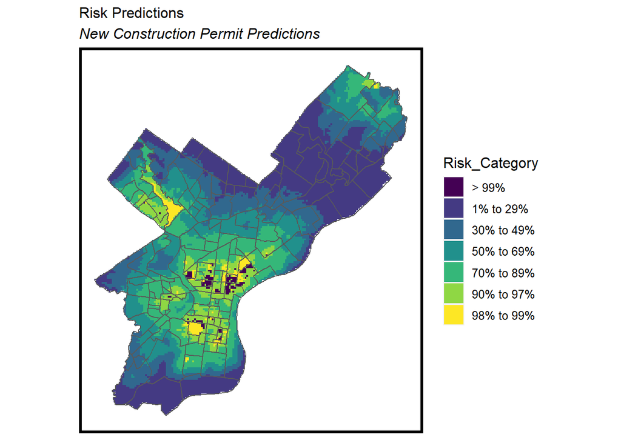

```r
permit_risk_sf <-
  filter(reg.summary, Regression == "Spatial LOGO-CV: Spatial Process") %>%
  mutate(label = "Risk Predictions",
         Risk_Category = ntile(Prediction, 100),
         Risk_Category = case_when(
           Risk_Category > 99 ~ "> 99%",
           Risk_Category >= 98 & Risk_Category <= 99 ~ "98% to 99%",
           Risk_Category >= 90 & Risk_Category <= 97 ~ "90% to 97%",
           Risk_Category >= 70 & Risk_Category <= 89 ~ "70% to 89%",
           Risk_Category >= 50 & Risk_Category <= 69 ~ "50% to 69%",
           Risk_Category >= 30 & Risk_Category <= 49 ~ "30% to 49%",
           Risk_Category >= 1 & Risk_Category <= 29 ~ "1% to 29%"))

permit_risk_sf %>%
  na.omit() %>%
  gather(Variable, Value, -label, -Risk_Category, -geometry) %>%
  ggplot() +
    geom_sf(aes(fill = Risk_Category), colour = NA) +
    geom_sf(data=nhood, fill = "transparent") +
    #geom_sf(data = sample_n(cvID, 300), size = .5, colour = "black") +
    #facet_wrap(~label, ) +
    scale_fill_viridis(discrete = TRUE) +
    labs(title="Risk Predictions",
         subtitle="New Construction Permit Predictions") +
    mapTheme()
```

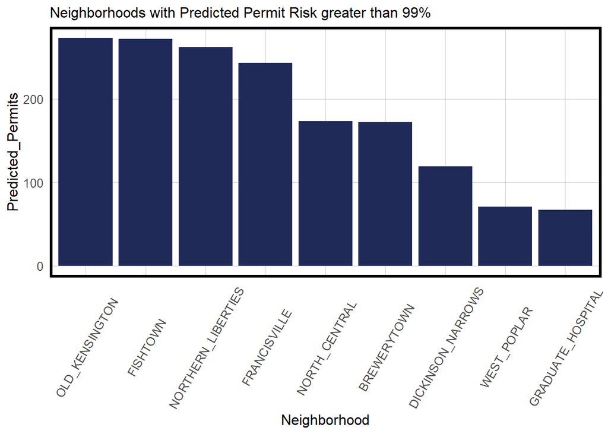

```r
# %>%
#   cbind(
#     aggregate(
#       dplyr::select(theft18) %>% mutate(theftCount = 1), ., sum) %>%
#       mutate(theftCount = replace_na(theftCount, 0))) %>%
#   dplyr::select(label,Risk_Category, theftCount)

# permit_risk_sf_nh_count <-
#   permit_risk_sf %>%
#   dplyr::select(cvID, countpermits, Risk_Category) %>%
#   st_drop_geometry() %>%
#   group_by(cvID) %>%
#   summarise(Predicted_Permits=sum(countpermits)) %>%
#   dplyr::filter(., Predicted_Permits>180) %>%
#   arrange(.,-Predicted_Permits) %>%
#   rename(Neighborhood = cvID) %>%
#   ggplot() +
#   geom_bar(aes(x=reorder(Neighborhood, -Predicted_Permits), Predicted_Permits), fill = "#1f2a59", stat = "identity") +
#   labs(x = "Neighborhood",
#        title = "Top 10 Neighborhoods by Predicted Permits") +
#   #scale_y_continuous(limits = c(0,100)) +
#   plotTheme()

 highest_risk_nhoods <-
  permit_risk_sf %>%
  dplyr::select(cvID, Risk_Category, countpermits) %>%
  dplyr::filter(., Risk_Category =="> 99%") %>%
  st_drop_geometry() %>%
  group_by(cvID) %>%
  summarise(Predicted_Permits=sum(countpermits)) %>%
  dplyr::filter(., Predicted_Permits>52) %>%
  arrange(.,-Predicted_Permits) %>%
  rename(Neighborhood = cvID)

  ggplot(highest_risk_nhoods) +
  geom_bar(aes(x=reorder(Neighborhood, -Predicted_Permits), Predicted_Permits), fill = "#1f2a59", stat = "identity") +
  labs(x = "Neighborhood",
       title = "Neighborhoods with Predicted Permit Risk greater than 99%") +
  #scale_y_continuous(limits = c(0,100)) +
    theme(axis.text.x=element_text(angle = 60, vjust=0.5))+
  plotTheme()
```

## Community Partners

As part of our analysis, we collected data on Registered Community Organizations (RCOs) in Philadelphia, including the RCO boundaries and primary contact information. We have matched the RCOs with Philadelphia neighborhoods and provided a table of each RCO that makes the contact information readily available. We intend this information to complement the results from our predictive analysis: as neighborhoods are identified as at risk to displacement, staff from the City may wish to contact trusted organizations in that location in order to begin a process to support longtime residents.

```r
nhood_name<- nhood%>% dplyr::select(name)%>%
  rename(Neighborhood=name)

rcos_final<-
  st_centroid(rcos)%>%
  st_join(nhood_name)%>%
  dplyr::select(ORGANIZATION_NAME, ORGANIZATION_ADDRESS, PRIMARY_NAME, PRIMARY_ADDRESS, PRIMARY_EMAIL, PRIMARY_PHONE, Neighborhood)%>%
  arrange(Neighborhood)

rcos_final<-rcos_final[c(7, 1, 2, 3, 4, 5, 6, 8)]
```

```r
st_drop_geometry(rcos_final) %>%
  kable(caption = "Registered Community Organizations by Neighborhood")%>%
    kable_styling("striped", full_width = T)%>%
  scroll_box(height = "300px")
```

Registered Community Organizations by Neighborhood

| Neighborhood | ORGANIZATION_NAME | ORGANIZATION_ADDRESS | PRIMARY_NAME | PRIMARY_ADDRESS | PRIMARY_EMAIL | PRIMARY_PHONE |
| --- | --- | --- | --- | --- | --- | --- |
| ALLEGHENY_WEST | RAH Civic Association | 3106 N. Spangler Street, 19132 | Rosalie Cooper | 3106 N Spangler Street, 19132 | rahcivicassociation@yahoo.com | (215)696-4832 |
| ALLEGHENY_WEST | Swampoodle Neighborhood Parcels Association | 1846 N 28th Street 19121 | Adrienne Fernandez | 1846 N 28th Street 19121 | swampoodleneighborhoodparcels@gmail.com | 2152796456 |
| ALLEGHENY_WEST | Community Action Group | 3149 N Pennock St, Philadelphia PA 19132 | Denise Whittaker | 3149 N Pennock St, Philadelphia PA 19132 | whittade@comcast.net | 2153602813 |
| BELLA_VISTA | Bella Vista Neighbors Association | PO Box 63955, 19147 | Dennis Hallda | P.O. Box 63955 Philadelphia, PA 19147 | zoning@bellavistaneighbors.org | 2156270057 |
| BELMONT | Belmont Alliance Civic Association CDC | 871 North Holly Street Floor #2, 19104 | Bettye Ferguson | 871 North Holly Street Floor #1, 19104 | belmontalliance@gmail.com | 2678822596 |
| BELMONT | Holly Street Neighbors CDC | 737 N. Holly Street Philadelphia, PA 19104 | Alverita Spain | 737 N. Holly Street Philadelphia, PA 19104 | hollystreetneighbors@gmail.com | 2152395305 |
| BELMONT | West Belmont Civic Association | 4311 Otter Street Philadelphia, PA 19104 | David Pickett | 4311 Otter Street Philadelphia, PA 19104 | depickett@westbelmontcivic.org | 2158735722 |
| BELMONT | Parkside Area Community Association | 4032 Parkside Avenue #2 Philadelphia , PA 19104 United States Philadelphia, PA 19131 | Netrisa Dockery | 4032 Parkside Avenue #2 Philadelphia, PA 19104 United States | netrisat@yahoo.com | 2676795812 |
| BELMONT | People’s Emergency Center Community Development Corporation | 325 N 39th St, 19104 | James Wright | 3939 Warren Street 2nd floor Philadelphia, PA 19104 | jameswright@pec-cares.org | 2677775853 |
| BREWERYTOWN | 29th Democratic Ward | 1233 north 29th street Philadelphia , Pennsylvania 19121 | Clyde Sanders | 2332 West Nicholas street Philadelphia , Pennsylvania 19121 | clydesanders74@gmail.com | 2157711819 |
| BREWERYTOWN | Celestial Community Development Corporation | 2800 W. Thompson Street, 19121 | Michelle Brownlee | 2800 W. Thompson Street Philadelphia, PA 19121 United States | celestialwordmin@gmail.com | 2155008013 |
| BREWERYTOWN | Brewerytown Sharswood Community Civic Association | 3000 “D” W Master Street 19121 | Warren McMichael | 2514 W Stewart Philadelphia, PA 19121 Philadelphia, PA 19121 | brew.sharsnas@gmail.com | 2157635507 |
| BRIDESBURG | Bridesburg Community Action Alliance | 4413 Garden Street | Yvonne Stephens | 4413 Garden Street | yvonnestephens2@yahoo.com | 2159150078 |
| BRIDESBURG | Bridesburg Civic Association | 2824 Plum Street, 19137 | Harry Enggasser | 2824 Plum Street, 19137 | henggasser@yahoo.com | 2672533189 |
| BUSTLETON | Greater Bustleton Civic League | 9823 Verree Rd Philadelphia Philadelphia, PA 19115 | Jack O’Hara | 9823 Verree Rd Philadelphia, PA 19115 | jackohara1@aol.com | 2156739519 |
| BYBERRY | Arbours at Eagle Pointe Community Association | 2675 Veronica Lane Phildelphia, PA 19116 | Robert Purvis | 15108 Dahlia Drive, 19116 | purbkkcm1@gmail.com | 2158802044 |
| CALLOWHILL | Callowhill Neighborhood Association | 1115 Hamilton St., 19123 | Sarah McEneaney | 1115 Hamilton St., 19123 | sarahmceneaney@me.com | 2156204647 |
| CARROLL_PARK | Parkside Association | Parkside Evans Recreation Center, 53rd & Parkside Avenue 19131 | Lucinda Hudson | 1719 N. 52nd Street Suite “G” 19131 | lhudson@parksideassociation.org | 2158699752 |
| CARROLL_PARK | Concerned Citizens Revitalization | 6010 Lansdowne Avenue, Philadelphia, PA 19131 | Gertrude Weaver | 6010 Lansdowne Avenue, Philadelphia, PA 19131 | weaversenergy@hotmail.com | 2158779411 |
| CARROLL_PARK | Hestonville Civic Association | 1623 55th Street, 19131 | Sheila Buchanan | 1623 North 55th Street, 19131 | hestonville@gmail.com | 2675047800 |
| CARROLL_PARK | Cathedral Park Community Development Association | P.O. Box 11796, Philadelphia, PA 19101 | Mark Frog Harris | P.O. Box 11796, Philadelphia, PA 19101 | MarkFrogHarris@verizon.net | 2156855340 |
| CEDAR_PARK | Cedar Park Neighbors | 4740 Baltimore Ave Philadelphia, PA 19143 | Shawn Markovich | C/O Cedar Park Neighbors 4740 Baltimore Ave Philadelphia, PA 19143 | zoning@cedarparkneighbors.org | 2672258283 |
| CEDAR_PARK | Cedar Point Park Neighborhood Association | c/o 4614 Cedar Avenue Philadelphia, PA 19143 | Theresa Sims | C/o 4614 Cedar Avenue Philadelphia, PA 19143 | cedarpointparkneighborhoodassociation@hotmail.com | 2152228020 |
| CEDAR_PARK | 46th Ward Democratic Committee | 4619 Chester Avenue, Philadelphia, PA 19143 | Catherine Blunt | 4918 Walton Avenue, Philadelphia, PA 19143 | 46wardrco@gmail.com | 2157471285 |
| CEDAR_PARK | Kingsessing Spirit | 5426 Baltimore Avenue Philadelphia, PA 10143 | Conor McAleer | 5426 Baltimore Ave, Philadelphia, PA 191430 | kingsessingspiritrco1@gmail.com | 6102124853 |
| CEDAR_PARK | 46th Republican Ward | 4256 Regent Square, Philadelphia PA 19104 | Denise Furey | 4256 Regent Square, Philadelphia PA 19104 | denise.furey@wolfe.org | 2152664121 |
| CEDARBROOK | 50th Democratic Ward | 7626 Forrest Avenue Philadelphia, PA 19150 | Gerry Sizemore | PO Box 27476, Philadelphia, 19118 | Grndmager@verizon.net | (215)549-7374 |
| CHESTNUT_HILL | 9th Republican Ward | 22 W. Southampton Ave Philadelphia, PA 19118 | Christopher Lins | 22 W. Southampton Ave, Philadelphia Pa 19118 | lins.christopher@gmail.com | 2152055776 |
| CHESTNUT_HILL | Chestnut Hill Conservancy | 8708 Germantown Ave, 19118 | Patricia Cove | 8504 Germantown Ave Philadelphia, PA 19118 | patricia@patriciacove.com | 2152483219 |
| CHESTNUT_HILL | Friends of the Wissahickon | 40 West Evergreen Avenue Suite 108 Philadelphia, PA 19118 | Ruffian Tittman | 40 West Evergreen Avenue Suite 108 Philadelphia, PA 19118 | tittmann@fow.org | 2152470417 |

[output cut: 251 more lines]

## Use Case & Improvements

Returning to our original use case, this analysis and model has successfully laid the foundation for achieving our vision of a Displacemnet Risk Tracking tool to be used by city governments.

1. Anticipating neighborhoods where home values may increase
- Achieved: This model accurately predicts the risk of new construction across the city, and has identified neighborhoods at risk of experiencing displacement. Our exploratory analysis has also indicated areas with large recent changes in home values.
  - Next steps: We would like to incorporate the recent change in home value into our Risk Map at the neighborhood level.
2. Identifying trusted community partners in each area of the city
- Achieved: A list of RCOs is joined into our neighborhood list.
  - Next Steps: We would like to create an interactive risk map that displays these partners upon clicking on a neighborhood on the map.
3. By estimating the benefit various policy levers, such as flip taxes or home renovation subsidies, can have on the long-time residents of each neighborhood.
- Achieved: We have indicated the changes in home value that have been recently occurring.
  - Next Steps: Ideally, we can quantify the effects of various policy levers. From there, we would automate a cost and benefit calculation using the quantified policy outcomes and home values.

We hope that other actors who are similarly concerned with homeowner displacement can continue to build upon both this model and dashboard tool. This kind of tool would be incredibly helpful to planners and policy makers attempting to stem what feels like an inevitable increase in displacement of long time residents in growing cities. Not only is this displacement not a given, but we currently have all the information needed to tackle the issue in a precise and data-driven way.

[^1]: Pew Charitable Trusts. 2016. Philadelphia’s Changing Neighborhoods: Gentrificaiton and other shifts since 2000. https://www.pewtrusts.org/~/media/assets/2016/05/philadelphias_changing_neighborhoods.pdf